# Notion d’échantillon et d’estimateurs

## Échantillonnage

### Introduction

Considérons une population P composée de N individus. On dispose par ailleurs d’un caractère statistique X observable sur chaque individu de P.

On note $x_1,x_2,\dots,x_n$ les valeurs de x sur les individus respectifs 1,2,3,…,N.

On note $\mu$ et $\sigma^2$ respectivement la moyenne et la variance de X sur toute la population P. On a donc :
$$\mu = \frac{1}{N} \sum_{i=1}^N X_i$$
et
$$\sigma^2 = \frac{1}{N} \sum_{i=1}^N ( X_i- \mu)^2$$

On prélève dans P un échantillon $E$ de $n$ individus (de taille $n$)

Les valeurs de $x_i$ qui sont obsérvé dépendent du tirage éffectué, on peut donc obsérvé aussi leurs moyenne et leurs variance. Les valeurs obsérvés ont donc un caractère aléatoire, et il est de meme de leur moyenne et variance, c’est deux dérniers sont notées $\overline{X}$ et $\sigma^{'2}$ avec
$$\overline{X} = \frac{1}{n} \sum_{i = 1}^n X_i$$
et
$$\sigma^2 = \frac{1}{n} \sum_{i=1}^n ( X_i- \overline{X})^2$$

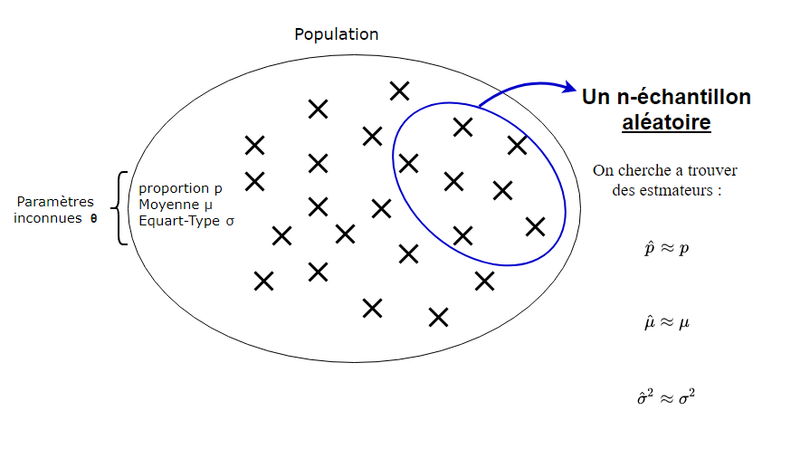

On note $\left(X_{1}, X_{2}, \dots, X_{n} \right)$ un n-échantillon aléatoire de la variable $X$ **indépendant et identiquement distribué**.

## Notion d’éstimateur

Un éstimateur est une formule qui est calculable dés qu’on fixe les valeurs de $X_i$

$\hat\theta = f(X_1,X_2,\dots,X_n)$

Exemple d’estimateur : l’estimateur naturel de la moyenne $\overline{X_n} = \frac{1}{n} \sum_{i = 1}^n X_i$

$\Rightarrow$ Une estimation est une application numérique de la formule de l’éstimateur (réalisation d’un échantillon)

### Exemples

On suppose qu’on a n-échantillon $(X_1,X_2,\dots,X_n)$ i.i.d (indépendants et identiquement distribués ) de la v.a (variable aléatoire) $X \sim \mathcal{N}(\mu , \sigma)$

$T_i$ est-il un éstimateur ?

**Rappel** un éstimateur est une expression mathématique qui est calculable numériquement si on connait les $X_i$

- $T_1 = X_1$ : oui
- $T_2 = 2X_2 + 1$ : oui
- $T_3 = \overline{X_n} = \frac{X_1+X_2+\cdots+X_n}{n}$ : oui
- $T_4 = \sin(X_1) + \sqrt{1+{X_2}^2}$ : oui
- $T_5 = \sum_{i=1}^{n} \frac{iX_i}{n}$ : oui
- $T_6 = \sum_{i=1}^{n} \frac{X_i + iX_i + X_i^2}{n^2 + n + 1}$ : oui
- $T_7 = \max(X_i)$ : oui
- $T_8 = \left\{ \begin{array}{ c l } \ 0 & \quad \textrm{si tous les } X_i \le 1 \\ 1 & \quad \textrm{sinon} \end{array} \right.$ : oui

### Contre exemples

- $T_9 = \theta$ : non car il dépend d’un paramètre inconnue
- $T_{10} = X_1 + \theta$ : non
- $T_{11} = \overline{X_n} - \sqrt{\theta^2 - 1}$ : non

Dans la suite on répond a la question : $T_i$ est-il un bon éstimateur ?

[output not shown]